# RNA 팀 군집분석

```python
from __future__ import print_function
from sklearn.datasets import make_blobs
from sklearn.cluster import KMeans
from sklearn.metrics import silhouette_samples, silhouette_score
from pandas import DataFrame
from scipy.stats import entropy
from math import log, e
import matplotlib.pyplot as plt
import matplotlib.cm as cm
import numpy as np
import pandas as pd
import math
import timeit
import matplotlib.pyplot as plt
plt.rcParams['font.family'].insert(0, 'Malgun Gothic')
plt.rcParams['font.family'] = 'Malgun Gothic'
%matplotlib inline
import seaborn as sns
import plotly.express as px
import plotly.io as pio
pio.renderers.default = "notebook_connected"

from sklearn.preprocessing import LabelEncoder, OneHotEncoder, StandardScaler
from sklearn.cluster import KMeans
from sklearn.decomposition import PCA

pd.set_option('display.float_format', lambda x: '%.2f' % x)
import warnings
warnings.filterwarnings('ignore')
```

```python
PatientInfo = pd.read_csv('C:/Users/82109/코로나 프로젝트 파이썬 파일/data/PatientInfo.csv')
```

```python
patientcount = PatientInfo.groupby('age').count().patient_id

fig = patientcount.iplot(asFigure=True, kind='bar')
fig.show()
```

[output not shown]

```python
p_info.info()
```

```
<class 'pandas.core.frame.DataFrame'>
RangeIndex: 5164 entries, 0 to 5163
Data columns (total 14 columns):
 #   Column              Non-Null Count  Dtype
---  ------              --------------  -----
 0   patient_id          5164 non-null   int64
 1   sex                 4042 non-null   object
 2   age                 3784 non-null   object
 3   country             5164 non-null   object
 4   province            5164 non-null   object
 5   city                5070 non-null   object
 6   infection_case      4245 non-null   object
 7   infected_by         1347 non-null   object
 8   contact_number      784 non-null    float64
 9   symptom_onset_date  690 non-null    object
 10  confirmed_date      5161 non-null   object
 11  released_date       1587 non-null   object
 12  deceased_date       66 non-null     object
 13  state               5164 non-null   object
dtypes: float64(1), int64(1), object(12)
memory usage: 564.9+ KB
```

```python
print(p_info.shape, len(p_info.patient_id.unique()))
```

```
(5164, 14) 5164
```

# 1. 전처리

## 1.1 감염 경로 (Infection_Case)

```python
print(len(p_info.infection_case.unique()))
p_info.infection_case.unique()
```

```
52
```

```
array(['overseas inflow', 'contact with patient', 'Seongdong-gu APT',
       'etc', "Eunpyeong St. Mary's Hospital", 'Shincheonji Church',
       'Dongan Church', 'Guro-gu Call Center', nan, 'Itaewon Clubs',
       'Samsung Medical Center', 'Biblical Language study meeting',
       'Coupang Logistics Center', 'Guri Collective Infection',
       'KB Life Insurance', 'Gangnam Dongin Church',
       'Korea Campus Crusade of Christ',
       'Yeongdeungpo Learning Institute', 'Yeonana News Class',
       'SMR Newly Planted Churches Group', 'Seocho Family',
       'Anyang Gunpo Pastors Group', 'Richway',
       'Samsung Fire & Marine Insurance', 'Yangcheon Table Tennis Club',
       'Yongin Brothers', 'Day Care Center',
       'Geumcheon-gu rice milling machine manufacture', 'Daezayeon Korea',
       'Orange Life', 'Daejeon door-to-door sales',
       'Seoul City Hall Station safety worker', 'Uiwang Logistics Center',
       'Wangsung Church', 'Gangnam Yeoksam-dong gathering',
       'Onchun Church', 'Cheongdo Daenam Hospital',
       'Suyeong-gu Kindergarten', 'Ministry of Oceans and Fisheries',
       'Orange Town', 'Dunsan Electronics Town',
       'gym facility in Cheonan', 'gym facility in Sejong',
       'River of Grace Community Church', 'Gyeongsan Seorin Nursing Home',
       'Gyeongsan Cham Joeun Community Center',
       'Gyeongsan Jeil Silver Town', 'Bonghwa Pureun Nursing Home',
       'Pilgrimage to Israel', 'Milal Shelter', 'Geochang Church',
       'Changnyeong Coin Karaoke'], dtype=object)
```

52개의 감염경로가 있는 것을 알 수 있음 > 이를 분류할 필요가 있음

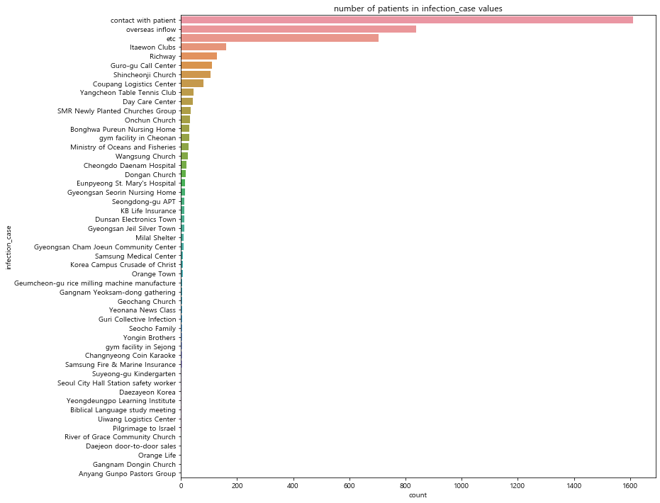

```python
t = p_info.pivot_table(index = 'infection_case', values = 'patient_id', aggfunc='count')
t.rename(columns = {'patient_id': 'count'}, inplace = True)
t = t.sort_values('count', ascending = False)

plt.figure(figsize = (12,12))
plt.title('number of patients in infection_case values')
sns.barplot(y = t.index, x= 'count', data = t)
display()
```

contact with patient 값에 신천지나 이태원 클럽에서 감염된 감염자와 접촉, 접촉 하여 N차 감염으로 분류될 수 있는 사람들도 있을 것이다. 그러나 여기서는 실제 집단감염이 일어난 장소에서 감염이 됐는지 아닌지로 분류를 하자면 contact with patient 분류에 속하는 확진자들은 집단감염이 아닌 소규모 감염으로 볼 수 있다.

그렇다면 집단감염은 어떻게 정의할 수 있을까? Case 데이터 파일에 infection_case에 따라서 집단감염인 경우 True 라고 나와있는 것을 볼 수 있다. 이를 이용하여 집단감염 여부가 True 인 case 들을 모두 '집단감염' 으로 분류할 수 있을 것이다.

```python
case = pd.read_csv('C:/Users/82109/코로나 프로젝트 파이썬 파일/data/Case.csv')
```

```python
case.head()
```

|  | case_id | province | city | group | infection_case | confirmed | latitude | longitude |
| --- | --- | --- | --- | --- | --- | --- | --- | --- |
| 0 | 1000001 | 서울 | 용산구 | True | Itaewon Clubs | 139 | 37.538621 | 126.992652 |
| 1 | 1000002 | 서울 | 관악구 | True | Richway | 119 | 37.48208 | 126.901384 |
| 2 | 1000003 | 서울 | 구로구 | True | Guro-gu Call Center | 95 | 37.508163 | 126.884387 |
| 3 | 1000004 | 서울 | 양천구 | True | Yangcheon Table Tennis Club | 43 | 37.546061 | 126.874209 |
| 4 | 1000005 | 서울 | 도봉구 | True | Day Care Center | 43 | 37.679422 | 127.044374 |

```python
case2 = case.groupby('infection_case')['group'].sum()
case2 = pd.DataFrame(case2)

case2.head()
```

| infection_case | group |
| --- | --- |
| Anyang Gunpo Pastors Group | 2.0 |
| Biblical Language study meeting | 1.0 |
| Bonghwa Pureun Nursing Home | 1.0 |
| Bundang Jesaeng Hospital | 1.0 |
| Changnyeong Coin Karaoke | 1.0 |

```python
t = t.merge(case2, left_on = 'infection_case', right_on = 'infection_case', how = 'left')
```

```python
t[t.group == 0]
```

| infection_case | count | group |
| --- | --- | --- |
| contact with patient | 1610 | 0.0 |
| overseas inflow | 839 | 0.0 |
| etc | 703 | 0.0 |

contact with patient, overseas inflow, etc 를 제외한 나머지 case 들을 모두 '집단감염'으로 분류할 수 있다. 문제는 위 세가지 case와 Null 값을 어떻게 분류하냐인데, etc의 경우 잘 모르는 것으로 판단하여 '감염경로불문'으로 overseas inflow 는 '해외감염' 으로 분류할 수 있을 것이다.

contact with patient 에 의한 감염은 다른 감염자들과 접촉하여 n차 감염이 된 경우이므로 그 의미를 살려 '개인적감염' 이라고 분류하고자 한다.

919개의 Null값의 경우 양이 상당히 많지만, 조사가 안될 경우를 고려하였을 때 모두 삭제하도록 한다.

```python
p_info = p_info[p_info.infection_case.notnull()]
p_info.info()
```

```
<class 'pandas.core.frame.DataFrame'>
Int64Index: 4245 entries, 0 to 5163
Data columns (total 14 columns):
 #   Column              Non-Null Count  Dtype
---  ------              --------------  -----
 0   patient_id          4245 non-null   int64
 1   sex                 3210 non-null   object
 2   age                 2957 non-null   object
 3   country             4245 non-null   object
 4   province            4245 non-null   object
 5   city                4189 non-null   object
 6   infection_case      4245 non-null   object
 7   infected_by         1346 non-null   object
 8   contact_number      728 non-null    float64
 9   symptom_onset_date  671 non-null    object
 10  confirmed_date      4242 non-null   object
 11  released_date       1013 non-null   object
 12  deceased_date       28 non-null     object
 13  state               4245 non-null   object
dtypes: float64(1), int64(1), object(12)
memory usage: 497.5+ KB
```

```python
def classification(x):

    if x == 'overseas inflow':
        y = '해외감염'
    elif x == 'contact with patient':
        y = '개인적감염'
    elif (x == 'etc'):
        y = '감염경로불문'
    else:
        y = '집단감염'

    return y

p_info['infection_case'] = p_info['infection_case'].apply(lambda x: classification(x))
p_info.head()
```

|  | patient_id | sex | age | country | province | city | infection_case | infected_by | contact_number | symptom_onset_date | confirmed_date | released_date | deceased_date | state |
| --- | --- | --- | --- | --- | --- | --- | --- | --- | --- | --- | --- | --- | --- | --- |
| 0 | 1000000001 | male | 50s | Korea | 서울 | 강서구 | 해외감염 | NaN | 75.0 | 2020-01-22 | 2020-01-23 | 2020-02-05 | NaN | released |
| 1 | 1000000002 | male | 30s | Korea | 서울 | 중랑구 | 해외감염 | NaN | 31.0 | NaN | 2020-01-30 | 2020-03-02 | NaN | released |
| 2 | 1000000003 | male | 50s | Korea | 서울 | 종로구 | 개인적감염 | 2002000001 | 17.0 | NaN | 2020-01-30 | 2020-02-19 | NaN | released |
| 3 | 1000000004 | male | 20s | Korea | 서울 | 마포구 | 해외감염 | NaN | 9.0 | 2020-01-26 | 2020-01-30 | 2020-02-15 | NaN | released |
| 4 | 1000000005 | female | 20s | Korea | 서울 | 성북구 | 개인적감염 | 1000000002 | 2.0 | NaN | 2020-01-31 | 2020-02-24 | NaN | released |

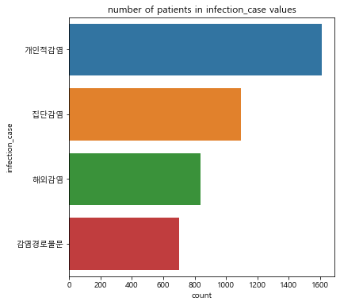

```python
t = p_info.pivot_table(index = 'infection_case', values = 'patient_id', aggfunc='count')
t.rename(columns = {'patient_id': 'count'}, inplace = True)
t = t.sort_values('count', ascending = False)

plt.figure(figsize = (6,6))
plt.title('number of patients in infection_case values')
sns.barplot(y = t.index, x= 'count', data = t)
display()
```

## 1.2 지역별 노인인구와 청년인구 비율

```python
region = pd.read_csv('C:/Users/82109/코로나 프로젝트 파이썬 파일/data/Region.csv')
```

```python
region
```

|  | code | province | city | latitude | longitude | elementary_school_count | kindergarten_count | university_count | academy_ratio | elderly_population_ratio | elderly_alone_ratio | nursing_home_count |
| --- | --- | --- | --- | --- | --- | --- | --- | --- | --- | --- | --- | --- |
| 0 | 10000 | 서울 | 서울 | 37.566953 | 126.977977 | 607 | 830 | 48 | 1.44 | 15.38 | 5.8 | 22739 |
| 1 | 10010 | 서울 | 강남구 | 37.518421 | 127.047222 | 33 | 38 | 0 | 4.18 | 13.17 | 4.3 | 3088 |
| 2 | 10020 | 서울 | 강동구 | 37.530492 | 127.123837 | 27 | 32 | 0 | 1.54 | 14.55 | 5.4 | 1023 |
| 3 | 10030 | 서울 | 강북구 | 37.639938 | 127.025508 | 14 | 21 | 0 | 0.67 | 19.49 | 8.5 | 628 |
| 4 | 10040 | 서울 | 강서구 | 37.551166 | 126.849506 | 36 | 56 | 1 | 1.17 | 14.39 | 5.7 | 1080 |
| ... | ... | ... | ... | ... | ... | ... | ... | ... | ... | ... | ... | ... |
| 239 | 61160 | 경상남도 | 하만 | 35.272481 | 128.406540 | 16 | 20 | 0 | 1.19 | 23.74 | 14.7 | 94 |
| 240 | 61170 | 경상남도 | 함양 | 35.520541 | 127.725177 | 13 | 12 | 0 | 1.01 | 32.65 | 20.9 | 83 |
| 241 | 61180 | 경상남도 | 합천 | 35.566702 | 128.165870 | 17 | 15 | 0 | 0.71 | 38.44 | 24.7 | 96 |
| 242 | 70000 | 제주도 | 제주도 | 33.488936 | 126.500423 | 113 | 123 | 4 | 1.53 | 15.10 | 6.4 | 1245 |
| 243 | 80000 | 대한민국 | 대한민국 | 37.566953 | 126.977977 | 6087 | 8837 | 340 | 1.56 | 15.67 | 7.2 | 94865 |

244 rows × 12 columns

```python
region.city.value_counts().head(10)
```

```
중구     6
동구     6
서구     5
북구     4
남구     4
광주     2
강서구    2
고성     2
전주시    1
원주시    1
Name: city, dtype: int64
```

```python
region.elderly_population_ratio.describe()
```

```
count    244.000000
mean      20.923730
std        8.087428
min        7.690000
25%       14.117500
50%       18.530000
75%       27.262500
max       40.260000
Name: elderly_population_ratio, dtype: float64
```

```python
l = region.elderly_population_ratio.values

bot = []
mid = []
top = []

for i in l :
    if i < 14 :
        bot.append(i)
    elif i >= 14 and i < 20 :
        mid.append(i)
    else :
        top.append(i)

print('고령화비율 14% 미만 도시의 수 :', len(bot), '/ 고령화비율 14~20% 도시의 수 :',len(mid),
      '/ 고령화비율 20% 이상 도시의 수 :', len(top))
```

```
고령화비율 14% 미만 도시의 수 : 60 / 고령화비율 14~20% 도시의 수 : 75 / 고령화비율 20% 이상 도시의 수 : 109
```

고령인구비율은 '65세 이상의 인구가 총인구에서 차지하는 비율'을 말하며, UN보고서 기준에 의해 7%는 고령화사회, 14%는 고령사회, 20%는 초고령사회에 진입하는 기준이 된다. 따라서 고령화비율 14%와 20%를 기준으로 '고령화도시', '고령도시', '초고령도시' 로 분류한다.

```python
region_epr = region[['province','city','elderly_population_ratio']]
region_epr.head()
```

|  | province | city | elderly_population_ratio |
| --- | --- | --- | --- |
| 0 | 서울 | 서울 | 15.38 |
| 1 | 서울 | 강남구 | 13.17 |
| 2 | 서울 | 강동구 | 14.55 |
| 3 | 서울 | 강북구 | 19.49 |
| 4 | 서울 | 강서구 | 14.39 |

```python
def aging(x) :
    if x < 14:
        return '고령화사회'
    elif x < 20:
        return '고령사회'
    else :
        return '초고령사회'

region_epr['City Age'] = region_epr.elderly_population_ratio.apply(lambda x : aging(x))
```

```python
p_info = p_info.merge(region_epr, left_on=['province','city'], right_on=['province','city'], how='left')
```

```python
p_info.info()
```

```
<class 'pandas.core.frame.DataFrame'>
Int64Index: 4245 entries, 0 to 4244
Data columns (total 16 columns):
 #   Column                    Non-Null Count  Dtype
---  ------                    --------------  -----
 0   patient_id                4245 non-null   int64
 1   sex                       3210 non-null   object
 2   age                       2957 non-null   object
 3   country                   4245 non-null   object
 4   province                  4245 non-null   object
 5   city                      4189 non-null   object
 6   infection_case            4245 non-null   object
 7   infected_by               1346 non-null   object
 8   contact_number            728 non-null    float64
 9   symptom_onset_date        671 non-null    object
 10  confirmed_date            4242 non-null   object
 11  released_date             1013 non-null   object
 12  deceased_date             28 non-null     object
 13  state                     4245 non-null   object
 14  elderly_population_ratio  4085 non-null   float64
 15  City Age                  4085 non-null   object
dtypes: float64(2), int64(1), object(13)
memory usage: 563.8+ KB
```

```python
p_info = p_info[p_info['City Age'].notnull()]
```

## 1.3 유동횟수

PatientRoute 데이터에 있는 확진자 ID 별 방문횟수를 세어 유동횟수(visit_count)라는 항목으로 추가한다.

```python
p_route = pd.read_csv('C:/Users/82109/코로나 프로젝트 파이썬 파일/data/PatientRoute.csv')
```

```python
p_route
```

|  | patient_id | global_num | date | province | city | type | latitude | longitude |
| --- | --- | --- | --- | --- | --- | --- | --- | --- |
| 0 | 1000000001 | 2.0 | 2020-01-22 | Gyeonggi-do | Gimpo-si | airport | 37.615246 | 126.715632 |
| 1 | 1000000001 | 2.0 | 2020-01-24 | Seoul | Jung-gu | hospital | 37.567241 | 127.005659 |
| 2 | 1000000002 | 5.0 | 2020-01-25 | Seoul | Seongbuk-gu | etc | 37.592560 | 127.017048 |
| 3 | 1000000002 | 5.0 | 2020-01-26 | Seoul | Seongbuk-gu | store | 37.591810 | 127.016822 |
| 4 | 1000000002 | 5.0 | 2020-01-26 | Seoul | Seongdong-gu | public_transportation | 37.563992 | 127.029534 |
| ... | ... | ... | ... | ... | ... | ... | ... | ... |
| 8087 | 6100000090 | NaN | 2020-03-24 | Seoul | Gangseo-gu | airport | 37.558654 | 126.794474 |
| 8088 | 6100000090 | NaN | 2020-03-24 | Busan | Gangseo-gu | airport | 35.173220 | 128.946459 |
| 8089 | 6100000090 | NaN | 2020-03-25 | Gyeongsangnam-do | Yangsan-si | store | 35.336944 | 129.026389 |
| 8090 | 6100000090 | NaN | 2020-03-25 | Gyeongsangnam-do | Yangsan-si | hospital | 35.335757 | 129.025003 |
| 8091 | 6100000090 | NaN | 2020-03-25 | Gyeongsangnam-do | Yangsan-si | store | 35.336944 | 129.026389 |

8092 rows × 8 columns

```python
p_route_pt = p_route.pivot_table(index = 'patient_id', values = 'type', aggfunc= 'count')
```

```python
p_route_pt2 = p_route.pivot_table(index = 'type', values = 'patient_id', aggfunc= 'count')
p_route_pt2.index
```

```
Index(['academy', 'administrative_area_level_1', 'airport', 'bakery', 'bank',
       'bar', 'beauty_salon', 'cafe', 'church', 'etc', 'gas_station', 'gym',
       'hospital', 'karaoke', 'lodging', 'park', 'pc_cafe', 'pharmacy',
       'post_office', 'public_transportation', 'real_estate_agency',
       'restaurant', 'school', 'store', 'university'],
      dtype='object', name='type')
```

```python
p_route_pt.rename(columns={'type':'visit_count'}, inplace=True)
p_route_pt.head()
```

| patient_id | visit_count |
| --- | --- |
| 1000000001 | 2 |
| 1000000002 | 13 |
| 1000000003 | 2 |
| 1000000004 | 1 |
| 1000000005 | 1 |

```python
p_info = p_info.merge(p_route_pt, left_on = 'patient_id', right_on = 'patient_id', how = 'left')
```

유동횟수를 셀 수 있는 데이터가 1334개만 존재한다. 약 2800개의 결측 id가 존재한다. 그렇다고 해당 id 들이 모두 이동하지 않고 집에만 있었다고 보기 어렵다. 따라서 결측치들을 모두 삭제한다.

```python
p_info = p_info[p_info.visit_count.notnull()]
```

```python
p_info.info()
```

```
<class 'pandas.core.frame.DataFrame'>
Int64Index: 1334 entries, 0 to 4023
Data columns (total 17 columns):
 #   Column                    Non-Null Count  Dtype
---  ------                    --------------  -----
 0   patient_id                1334 non-null   int64
 1   sex                       1091 non-null   object
 2   age                       1091 non-null   object
 3   country                   1334 non-null   object
 4   province                  1334 non-null   object
 5   city                      1334 non-null   object
 6   infection_case            1334 non-null   object
 7   infected_by               342 non-null    object
 8   contact_number            312 non-null    float64
 9   symptom_onset_date        261 non-null    object
 10  confirmed_date            1334 non-null   object
 11  released_date             393 non-null    object
 12  deceased_date             9 non-null      object
 13  state                     1334 non-null   object
 14  elderly_population_ratio  1334 non-null   float64
 15  City Age                  1334 non-null   object
 16  visit_count               1334 non-null   float64
dtypes: float64(3), int64(1), object(13)
memory usage: 187.6+ KB
```

## 1.4 성별(SEX)과 연령대(AGE)

```python
p_info = p_info[p_info.sex.notnull() & p_info.age.notnull()]
```

```python
from sklearn.preprocessing import LabelEncoder

le = LabelEncoder()

p_info['sex'] = le.fit_transform(p_info.sex)
p_info.head(3)
```

|  | patient_id | sex | age | country | province | city | infection_case | infected_by | contact_number | symptom_onset_date | confirmed_date | released_date | deceased_date | state | elderly_population_ratio | City Age | visit_count |
| --- | --- | --- | --- | --- | --- | --- | --- | --- | --- | --- | --- | --- | --- | --- | --- | --- | --- |
| 0 | 1000000001 | 1 | 50s | Korea | 서울 | 강서구 | 해외감염 | NaN | 75.0 | 2020-01-22 | 2020-01-23 | 2020-02-05 | NaN | released | 14.39 | 고령사회 | 2.0 |
| 1 | 1000000002 | 1 | 30s | Korea | 서울 | 중랑구 | 해외감염 | NaN | 31.0 | NaN | 2020-01-30 | 2020-03-02 | NaN | released | 16.65 | 고령사회 | 13.0 |
| 2 | 1000000003 | 1 | 50s | Korea | 서울 | 종로구 | 개인적감염 | 2002000001 | 17.0 | NaN | 2020-01-30 | 2020-02-19 | NaN | released | 18.27 | 고령사회 | 2.0 |

```python
def converter(x):
    x = x[:-1]
    x = int(x)
    return x

p_info['age'] = p_info.age.apply(lambda x : converter(x))
```

```python
p_info.info()
```

```
<class 'pandas.core.frame.DataFrame'>
Int64Index: 1091 entries, 0 to 4023
Data columns (total 17 columns):
 #   Column                    Non-Null Count  Dtype
---  ------                    --------------  -----
 0   patient_id                1091 non-null   int64
 1   sex                       1091 non-null   int32
 2   age                       1091 non-null   int64
 3   country                   1091 non-null   object
 4   province                  1091 non-null   object
 5   city                      1091 non-null   object
 6   infection_case            1091 non-null   object
 7   infected_by               335 non-null    object
 8   contact_number            308 non-null    float64
 9   symptom_onset_date        240 non-null    object
 10  confirmed_date            1091 non-null   object
 11  released_date             393 non-null    object
 12  deceased_date             9 non-null      object
 13  state                     1091 non-null   object
 14  elderly_population_ratio  1091 non-null   float64
 15  City Age                  1091 non-null   object
 16  visit_count               1091 non-null   float64
dtypes: float64(3), int32(1), int64(2), object(11)
memory usage: 149.2+ KB
```

# 2. 군집분석 모델 적용

## 2.1 Feature Transform

```python
data = p_info[['patient_id',
       'sex',
       'infection_case',
       'City Age',
        'visit_count']]

data.reset_index(drop= True, inplace= True)
print(data.shape)
data
```

```
(1091, 5)
```

|  | patient_id | sex | infection_case | City Age | visit_count |
| --- | --- | --- | --- | --- | --- |
| 0 | 1000000001 | 1 | 해외감염 | 고령사회 | 2.00 |
| 1 | 1000000002 | 1 | 해외감염 | 고령사회 | 13.00 |
| 2 | 1000000003 | 1 | 개인적감염 | 고령사회 | 2.00 |
| 3 | 1000000004 | 1 | 해외감염 | 고령사회 | 1.00 |
| 4 | 1000000005 | 0 | 개인적감염 | 고령사회 | 1.00 |
| ... | ... | ... | ... | ... | ... |
| 1086 | 6100000086 | 1 | 감염경로불문 | 고령화사회 | 4.00 |
| 1087 | 6100000087 | 0 | 감염경로불문 | 고령화사회 | 8.00 |
| 1088 | 6100000088 | 1 | 감염경로불문 | 고령화사회 | 24.00 |
| 1089 | 6100000089 | 1 | 감염경로불문 | 초고령사회 | 2.00 |
| 1090 | 6100000090 | 1 | 해외감염 | 고령화사회 | 7.00 |

1091 rows × 5 columns

```python
data_ = data[['sex',
       'infection_case',
       'City Age',
        'visit_count']]
data_ = pd.get_dummies(data_)
data_
```

|  | sex | visit_count | infection_case_감염경로불문 | infection_case_개인적감염 | infection_case_집단감염 | infection_case_해외감염 | City Age_고령사회 | City Age_고령화사회 | City Age_초고령사회 |
| --- | --- | --- | --- | --- | --- | --- | --- | --- | --- |
| 0 | 1 | 2.00 | 0 | 0 | 0 | 1 | 1 | 0 | 0 |
| 1 | 1 | 13.00 | 0 | 0 | 0 | 1 | 1 | 0 | 0 |
| 2 | 1 | 2.00 | 0 | 1 | 0 | 0 | 1 | 0 | 0 |
| 3 | 1 | 1.00 | 0 | 0 | 0 | 1 | 1 | 0 | 0 |
| 4 | 0 | 1.00 | 0 | 1 | 0 | 0 | 1 | 0 | 0 |
| ... | ... | ... | ... | ... | ... | ... | ... | ... | ... |
| 1086 | 1 | 4.00 | 1 | 0 | 0 | 0 | 0 | 1 | 0 |
| 1087 | 0 | 8.00 | 1 | 0 | 0 | 0 | 0 | 1 | 0 |
| 1088 | 1 | 24.00 | 1 | 0 | 0 | 0 | 0 | 1 | 0 |
| 1089 | 1 | 2.00 | 1 | 0 | 0 | 0 | 0 | 0 | 1 |
| 1090 | 1 | 7.00 | 0 | 0 | 0 | 1 | 0 | 1 | 0 |

1091 rows × 9 columns

```python
X = data_.values

scaler = StandardScaler()
X = scaler.fit_transform(X)
```

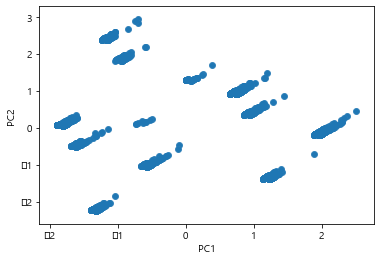

```python
pca = PCA(n_components = 2)
principalComponents = pca.fit_transform(X)
principalDF = pd.DataFrame(data = principalComponents, columns = ['PC1', 'PC2'])

ax = sns.scatterplot(x='PC1', y='PC2', data = principalDF)
sns.regplot(x=principalDF['PC1'], y=principalDF['PC2'], fit_reg=False)

display()
```

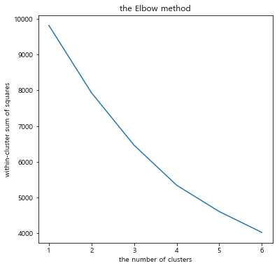

```python
cluster_range = range(1,7)
cluster_errors = []
for n in cluster_range:
    cluster = KMeans(n)
    cluster.fit(X)
    cluster_errors.append(cluster.inertia_)

plt.figure(figsize = (6,6))
plt.plot(cluster_range, cluster_errors)
plt.title('the Elbow method')
plt.xlabel('the number of clusters')
plt.ylabel('within-cluster sum of squares')
display()
```

```python
km = KMeans(n_clusters = 4)
km.fit(X)

centroids = km.cluster_centers_
labels= km.labels_
data_['label'] = labels
```

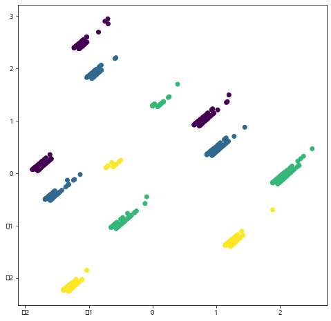

```python
pca = PCA(n_components = 2)
principalComponents = pca.fit_transform(X)
principalDF = pd.DataFrame(data = principalComponents, columns = ['PC1', 'PC2'])

plt.figure(figsize = (8,8))
plt.scatter('PC1', 'PC2', data = principalDF, c = labels)

display()
```

```python
data.groupby('label')['patient_id'].count()
```

```
label
0    359
1    214
2    278
3    240
Name: patient_id, dtype: int64
```

```python
data
```

|  | patient_id | sex | infection_case | City Age | visit_count | label |
| --- | --- | --- | --- | --- | --- | --- |
| 0 | 1000000001 | 1 | 해외감염 | 고령사회 | 2.00 | 3 |
| 1 | 1000000002 | 1 | 해외감염 | 고령사회 | 13.00 | 3 |
| 2 | 1000000003 | 1 | 개인적감염 | 고령사회 | 2.00 | 0 |
| 3 | 1000000004 | 1 | 해외감염 | 고령사회 | 1.00 | 3 |
| 4 | 1000000005 | 0 | 개인적감염 | 고령사회 | 1.00 | 0 |
| ... | ... | ... | ... | ... | ... | ... |
| 1086 | 6100000086 | 1 | 감염경로불문 | 고령화사회 | 4.00 | 1 |
| 1087 | 6100000087 | 0 | 감염경로불문 | 고령화사회 | 8.00 | 1 |
| 1088 | 6100000088 | 1 | 감염경로불문 | 고령화사회 | 24.00 | 1 |
| 1089 | 6100000089 | 1 | 감염경로불문 | 초고령사회 | 2.00 | 1 |
| 1090 | 6100000090 | 1 | 해외감염 | 고령화사회 | 7.00 | 3 |

1091 rows × 6 columns

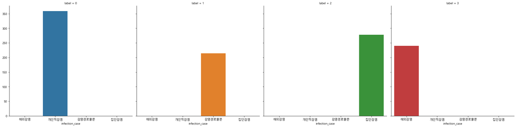

```python
g = sns.FacetGrid(data, col = 'label',  height = 6, sharey = True, sharex = True,
                  hue= 'label')

g.map(sns.countplot, "infection_case", order = ['해외감염', '개인적감염', '감염경로불문', '집단감염'])

ax0, ax1, ax2, ax3 = g.axes[0]

display()
```

```python
g = pd.DataFrame(data.groupby(['label', 'patient_id'])['visit_count'].sum())
g
```

| label | patient_id | visit_count |
| --- | --- | --- |
| 0 | 1000000003 | 2.00 |
|  | 1000000005 | 1.00 |
|  | 1000000006 | 1.00 |
|  | 1000000007 | 1.00 |
|  | 1000000010 | 4.00 |
| ... | ... | ... |
| 3 | 4100000143 | 5.00 |
|  | 5000000001 | 9.00 |
|  | 5100000006 | 2.00 |
|  | 6100000085 | 1.00 |
|  | 6100000090 | 7.00 |

1091 rows × 1 columns

```python
g.reset_index(inplace = True)
g['label'] = g['label'].astype('category')
g
```

|  | index | label | patient_id | visit_count |
| --- | --- | --- | --- | --- |
| 0 | 0 | 0 | 1000000003 | 2.00 |
| 1 | 1 | 0 | 1000000005 | 1.00 |
| 2 | 2 | 0 | 1000000006 | 1.00 |
| 3 | 3 | 0 | 1000000007 | 1.00 |
| 4 | 4 | 0 | 1000000010 | 4.00 |
| ... | ... | ... | ... | ... |
| 1086 | 1086 | 3 | 4100000143 | 5.00 |
| 1087 | 1087 | 3 | 5000000001 | 9.00 |
| 1088 | 1088 | 3 | 5100000006 | 2.00 |
| 1089 | 1089 | 3 | 6100000085 | 1.00 |
| 1090 | 1090 | 3 | 6100000090 | 7.00 |

1091 rows × 4 columns

```python
g_ = g.melt(id_vars= ['label', 'patient_id'], value_vars=['visit_count'],
        var_name='route', value_name='route_sum')
```

```python
g__ = g_.groupby(['label','route'])['route_sum'].mean()
g__ = pd.DataFrame(g__)
g__ = g__.reset_index()
g__
```

|  | label | route | route_sum |
| --- | --- | --- | --- |
| 0 | 0 | visit_count | 5.20 |
| 1 | 1 | visit_count | 6.64 |
| 2 | 2 | visit_count | 6.46 |
| 3 | 3 | visit_count | 4.57 |

```python
g_sum = g__.groupby('label')['route_sum'].sum()
g_sum = pd.DataFrame(g_sum)
g_sum
```

| label | route_sum |
| --- | --- |
| 0 | 5.20 |
| 1 | 6.64 |
| 2 | 6.46 |
| 3 | 4.57 |